# Hunt for the Pangrams

## Safe analysis despite data prep failures

Before completely calling it, we can used the data we successfully parsed off the HTML pages (not the image data) to see if there is a simple relationship between the genius score and the number of pangrams:

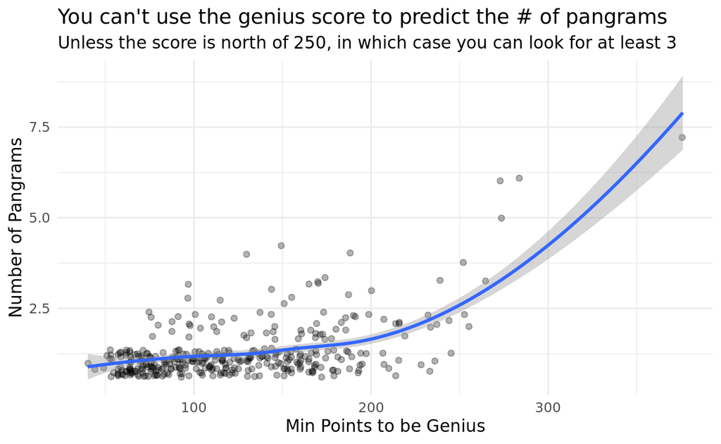

```r
data %>%
  select(-letters) %>%
  unique() %>%
  ggplot(aes(min_genius, num_pangram)) +
  geom_jitter(alpha = 0.3) +
    geom_smooth() +
    labs(
      title = "You can't use the genius score to predict the # of pangrams",
      subtitle = "Unless the score is north of 250, in which case you can look for at least 3",
      y = "Number of Pangrams",
      x = "Min Points to be Genius"
    ) +
    theme_minimal()
```

There is not a great relationship. There are a lot of games where there is only one pangram and the scores in those games varies significantly! This chart shows us that there are some outlying games with more than 4 pangrams, and that those mega-games tend to be correlated with high scores. But score alone won’t help you guess whether the game has 1, 2, 3, or 4 pangrams.

We can tell there is not a statistically significant difference if we compare the IQR within the box plots:

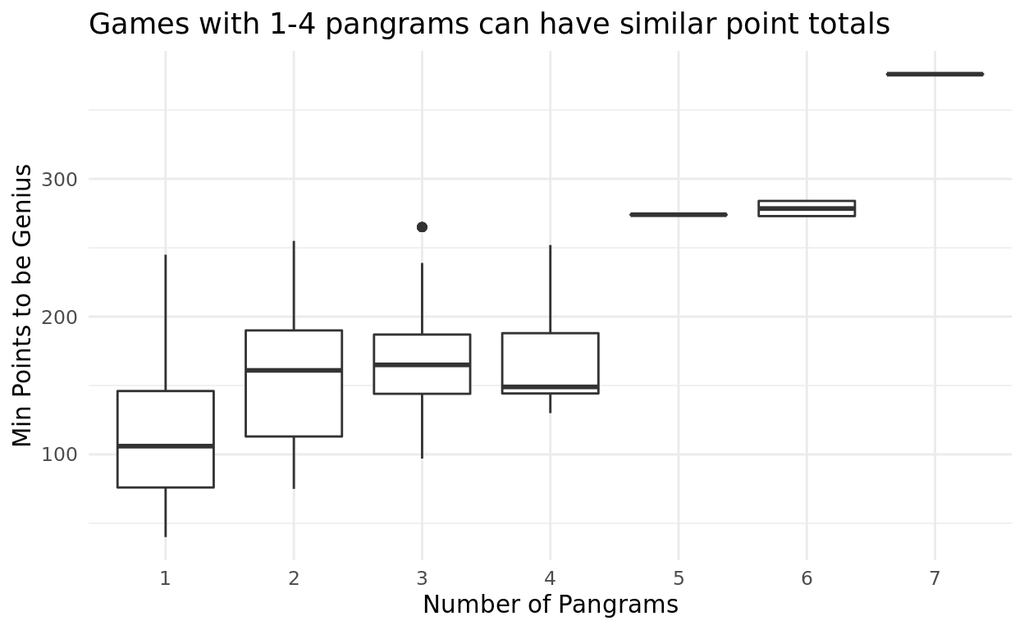

```r
ggplot(data, aes(as.factor(num_pangram), min_genius)) +
  geom_boxplot() +
  labs(
    x = "Number of Pangrams",
    y = "Min Points to be Genius",
    title = "Games with 1-4 pangrams can have similar point totals"
  ) +
  theme_minimal()
```

Finally, we can use the scraped data to double check that the game makers fairly assign the minimum genius score, by looking at the percentage of total points you have to get to be considered a genius:

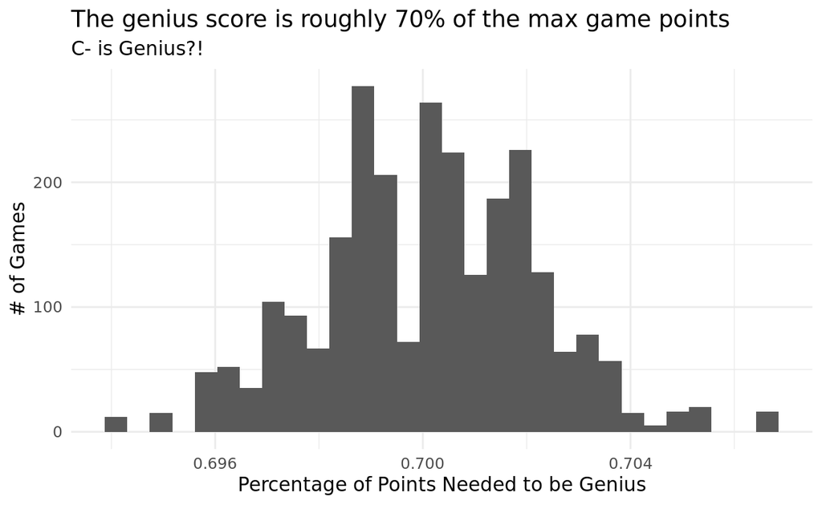

```r
data %>%
  mutate(perc_genius = min_genius / max_score) %>%
  ggplot(aes(perc_genius)) +
  geom_histogram() +
  theme_minimal() +
  labs(
    x = "Percentage of Points Needed to be Genius",
    y = "# of Games",
    title = "The genius score is roughly 70% of the max game points",
    subtitle = "C- is Genius?!"
  )
```

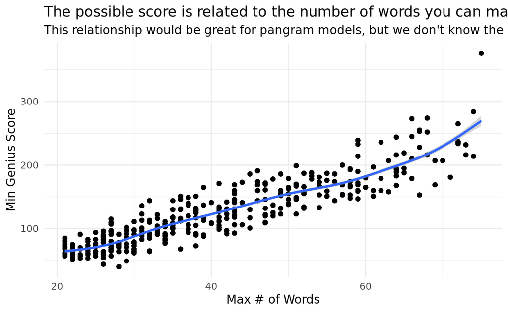

```r
ggplot(data, aes(max_words, min_genius)) +
  geom_point() +
  geom_smooth() +
  theme_minimal() +
  labs(
    x = "Max # of Words",
    y = "Min Genius Score",
    title = "The possible score is related to the number of words you can make",
    subtitle = "This relationship would be great for pangram models, but we don't know the # of words ahead of playing"
  )
```

As expected, given how the scoring works, the score (proxied by the minimum genius score) is closely correlated with the maximum number of words, but there is some variance. In fact, discrepancies between this relationship might point at games with a large number of pangrams! However, we don’t know the number of words going into a game, so this information wouldn’t help a player identify how many pangrams there may be. That said, we can safely assume that if genius score is high, the puzzle likely has more words!

Finally, one last area of investigation we could safely look at with our data is how the occurence of pangrams have changed over time. Are we getting more pangrams?

```r
data %>%
  group_by(date) %>%
  filter(num_pangram > 1) %>%
  select(-letters, -req_letter, -total_letters_found) %>%
  unique() %>%
  arrange(desc(num_pangram))
```

```
# A tibble: 78 x 5
# Groups:   date [78]
   date                     num_pangram max_score max_words min_genius
   <chr>                          <dbl>     <dbl>     <dbl>      <dbl>
 1 Friday, January 22, 2021           7       537        75        376
 2 Monday, May 24, 2021               6       406        74        284
 3 Wednesday, May 5, 2021             6       390        66        273
 4 Thursday, February 11, …           5       392        68        274
 5 Friday, December 4, 2020           4       186        38        130
 6 Monday, May 31, 2021               4       269        53        188
 7 Sunday, May 9, 2021                4       360        68        252
 8 Sunday, September 20, 2…           4       213        37        149
 9 Monday, February 1, 2021           3       379        72        265
10 Saturday, August 8, 2020           3       249        46        174
# … with 68 more rows
```

## Sketchy and biased analysis

Using the biased data that I had, I was curious if there was any pattern between a required letter and the likelihood of more than 2 pangrams? In other words, if I see a certain required letter, should I be on the pangram hunt?

```r
data %>%
  filter(total_letters_found == 7) %>%
  select(-letters) %>%
  unique() %>%
  group_by(req_letter) %>%
  filter(num_pangram > 2) %>%
  count() %>%
  arrange(desc(n)) %>%
  rename(`Number of games > 2 pangrams` = n)
```

```
# A tibble: 3 x 2
# Groups:   req_letter [3]
  req_letter `Number of games > 2 pangrams`
  <chr>                               <int>
1 T                                       4
2 Y                                       2
3 K                                       1
```

Really interesting! I would have expected more pangrams if the required letter was a vowel.

I looked at some of the specific date where OCR failed, especially our outlier day of Jan 22, 2021, and low and behold, these mis-placed days often DID have vowels as the required letter. Our conclusions here are sketchy. Garbage in, garbage out. Always get your data prep right!

Just how biased is our missing data w.r.t pangrams?

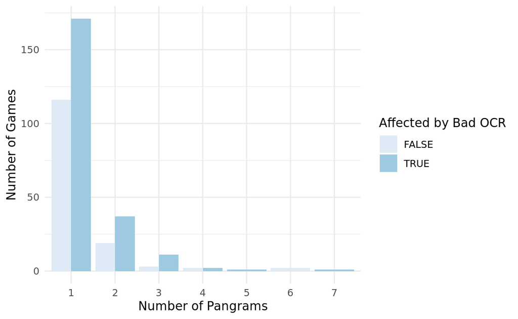

```r
data %>%
  select(-letters) %>%
  unique() %>%
  mutate(bad_data = ifelse(total_letters_found == 7, FALSE, TRUE)) %>%
  ggplot() +
  geom_bar(aes(as.factor(num_pangram), fill = bad_data), position = "dodge") +
  labs(
    x = "Number of Pangrams",
    y = "Number of Games",
    fill = "Affected by Bad OCR"
  ) +
  scale_fill_brewer() +
  theme_minimal()
```

## More on the data prep

So what is the deal with OCR? Each of the nytbee webpages with historical spelling bee data has an image that represents the game board:

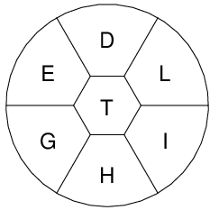

My goal in doing the data preparation was to parse all of the historical webpages, and as part of the parsing, convert this image into tidy data. I wanted to know the letters available on the board each day, along with the required center letter.

It turns out, parsing this image was harder than expected. My ultimate strategy was to use OpenCV to find the letters in the inage, and then use tesseract to identify the character. I’ll walk through the Python code below, including helpful images along the way.

I used a Python container running in Kubernetes for my work. The container hepled me easily create a virtualenv and a system environment with the proper OpenCV and Tesseract dependencies, and Kubernetes was just what I had around for running the container on a nicely networked EC2 instance.

```python
# first load the img
import skimage
import cv2
url = "https://nytbee.com/pics/20210531.png"
img = io.imread(url)
```

[figure not shown]

```python
# next identify the countours
gray = cv2.cvtColor(img, cv2.COLOR_BGR2GRAY)

# find the contours
contours,_=cv2.findContours(gray, cv2.RETR_TREE,
                            cv2.CHAIN_APPROX_SIMPLE)


# Loop through the contours... I used a trick to separate the letter contours from the polygon contours based on their area
# for the first loop we'll eliminate the polygon lines
img2 = img.copy()
for cnt in contours :
      # for each countour rough out the area size
      area = cv2.contourArea(cnt)

      # if the area is large its a polygon not a letter, so flag it
      if area > 400:
        approx = cv2.approxPolyDP(cnt,
                                  0.009 * cv2.arcLength(cnt, True), True)
        cv2.drawContours(img2, [cnt], 0, (255,255,255), 4)

cv2.imwrite("polygons.png", img2)
```

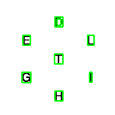

```python
# now we loop through the smaller "letter" polygons
# here I will show you the boxes
for cnt in contours :
      # for each countour rough out the area size
      area = cv2.contourArea(cnt)

      # if the area is small zoom in on it as a letter
      if area < 300:
         x, y, w, h = cv2.boundingRect(cnt)
         rect = cv2.rectangle(img2, (x, y), (x + w, y + h), (0, 255, 0), 2)


cv2.imwrite("letters.png", img2)
```

```python
# finally, this time as we loop through, we'll run the predictions using tesseract
ocr_letters = list()
for cnt in contours :
    # for each countour rough out the area size
    area = cv2.contourArea(cnt)

    # if the area is small, then figure out the letter!
    if area <300:
      x, y, w, h = cv2.boundingRect(cnt)
      cropped = img2[y:y + h, x:x + w]
      ocr_letters.append(pytesseract.image_to_string(cropped, config="--psm 10"))
```

```
['H\n\x0c', '|\n\x0c', 'G\n\x0c', 'T\n\x0c', '[L\n\x0c', 'E\n\x0c', 'D\n\x0c']
```

To view the full prep code, take a look at `ocr.py` in the GitHub repository. The letters are mostly correct, we just need to clean up the predictions a bit.

At this point though, it’d be good to understand why we are doing so poorly on some images! And that is a post for another holiday…